# Classification and Regression Trees

# Load data

```r
library(readr)
library(tidyverse)
library(visdat)
stevens <- read_csv("~/Documents/Online Classes/analytics-edge/stevens.csv")
glimpse(stevens)
```

```
Observations: 566
Variables: 9
$ Docket     <chr> "93-1408", "93-1577", "93-1612", "94-623", "94-1175", "95-129", ...
$ Term       <int> 1994, 1994, 1994, 1994, 1995, 1995, 1996, 1997, 1997, 1999, 1999...
$ Circuit    <chr> "2nd", "9th", "5th", "1st", "7th", "9th", "FED", "9th", "DC", "1...
$ Issue      <chr> "EconomicActivity", "EconomicActivity", "EconomicActivity", "Eco...
$ Petitioner <chr> "BUSINESS", "BUSINESS", "BUSINESS", "BUSINESS", "BUSINESS", "BUS...
$ Respondent <chr> "BUSINESS", "BUSINESS", "BUSINESS", "BUSINESS", "BUSINESS", "BUS...
$ LowerCourt <chr> "liberal", "liberal", "liberal", "conser", "conser", "conser", "...
$ Unconst    <int> 0, 0, 0, 0, 0, 1, 0, 1, 0, 0, 0, 1, 1, 0, 0, 0, 0, 0, 0, 0, 1, 0...
$ Reverse    <int> 1, 1, 1, 1, 1, 0, 1, 1, 1, 1, 1, 1, 1, 0, 0, 1, 1, 1, 1, 0, 0, 1...
```

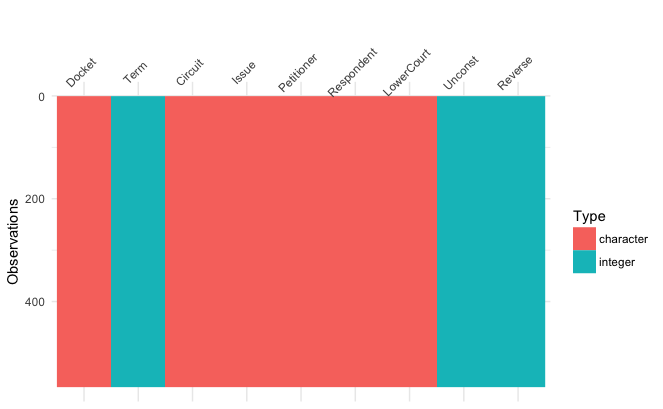

```r
vis_dat(stevens, sort_type = FALSE)
```

# Create Train and Test Data

We will split the data based on the desired output variable, which in this case is `Reverse`. First we use `sample.split` (from the `caTools` package) to divide up proportionally based on the output (`Reverse`). Then we use `subset` to create our training and testing sets.

```r
library(caTools)
set.seed(3000)
spl <- sample.split(stevens$Reverse, SplitRatio = 0.7)
Train <- subset(stevens, spl == TRUE)
Test <- subset(stevens, spl == FALSE)
```

# Build CART model

In this tutorial we will be using the `rpart` and `rpart.plot` packages, although I’ll show how this can be done using the `caret` package as this is probably the more popular and feature-rich option. I also want to try out the `FFTrees` package, but we’ll see if I have time to do so here.

```r
library(rpart)
library(rpart.plot)
StevensTree <- rpart(Reverse ~ Circuit + Issue + Petitioner + Respondent + LowerCourt + Unconst, data = Train, method = "class", minbucket = 25)
```

## Plot the Tree

We will use the `prp` function to create our Tree visualization

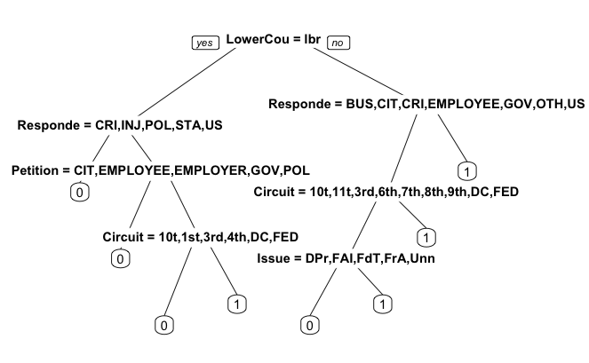

```r
prp(StevensTree)
```

# Assess the CART model

We will now assess how well our model predicts the desired output.

## Make Predictions

```r
PredictCART <- predict(StevensTree, newdata = Test, type="class")
```

## Confusion Matrix

```r
table(Test$Reverse, PredictCART)
```

```
   PredictCART
     0  1
  0 41 36
  1 22 71
```

This gives us an accuracy of 0.6588235.

## Make an ROC curve

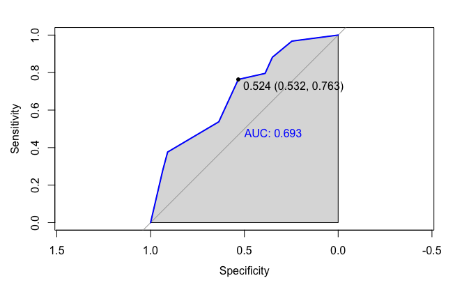

```r
library(pROC)
predictROC <- predict(StevensTree, newdata = Test)
pred_ROC <- roc(Test$Reverse, predictROC[,2])
plot(pred_ROC, col="blue",
     print.thres = "best",
     print.auc = TRUE,
     auc.polygon = TRUE,
     )
```

# Random Forests

Improves the predictive accuracy of CART by building a bunch of CART *trees*. However, the downside of this is that is is *less* interpretable than CART trees. For more convincing about the magic of Random Forests, check out [this article](https://machinelearningmastery.com/use-random-forest-testing-179-classifiers-121-datasets/). (h/t: [partially derivative](http://partiallyderivative.com/news/2014/12/19/episode-6-the-one-about-star-trek-zombies-and-contraceptives))

> Random **forest** works by constructing a lot of CART **trees**.

How are the trees built? Each tree splits on a random subset of the independent variables and is built from a “bagged”/“bootstrapped” sample of the data. In this process, the data is selected randomly *with replacement*.

**Random Forest Paremeters:**

- `nodesize` - the minimum number of observations to subset
- `ntree` - the number of trees to create in our forest

## Build a Model

```r
library(randomForest)
# StevensForest <- randomForest(Reverse ~ Circuit + Issue + Petitioner + Respondent + LowerCourt + Unconst, data = Train, nodesize=25, ntree=200)
```

The above code that is preceded by an octothorpe (#) will not work because `randomForest` does not offer a `method = class` argument. To bypass this, we will need to convert the desired output, `Reverse`, to a factor.

```r
Train$Reverse <- as.factor(Train$Reverse)
Test$Reverse <- as.factor(Test$Reverse)
```

Now that `Reverse` is a factor, we can try create a predictive model using the `randomForest` function again.

```r
StevensForest = randomForest(Reverse ~ Circuit + Issue + Petitioner + Respondent + LowerCourt + Unconst, data = Train, nodesize=25)
```

```
NAs introduced by coercionNAs introduced by coercionNAs introduced by coercionNAs introduced by coercionNAs introduced by coercionError in randomForest.default(m, y, ...) :
  NA/NaN/Inf in foreign function call (arg 1)
```

We are still getting Error Messages. How do we fix this? The `randomForest` function is unable to process the `chr` variables, so these too will need to be converted to factors.

```r
stevens$Docket <- as.factor(stevens$Docket)
stevens$Circuit <- as.factor(stevens$Circuit)
stevens$Issue <- as.factor(stevens$Issue)
stevens$Petitioner <- as.factor(stevens$Petitioner)
stevens$Respondent <- as.factor(stevens$Respondent)
stevens$LowerCourt <- as.factor(stevens$LowerCourt)
Train <- subset(stevens, spl == TRUE)
Test <- subset(stevens, spl == FALSE)
glimpse(Train)
```

```
Observations: 396
Variables: 9
$ Docket     <fctr> 93-1577, 94-1175, 95-728, 96-843, 98-1480, 99-150, 99-1571, 99-...
$ Term       <int> 1994, 1995, 1996, 1997, 1999, 1999, 2000, 2000, 1994, 1999, 1996...
$ Circuit    <fctr> 9th, 7th, FED, DC, 11th, 2nd, 6th, 9th, 7th, 3rd, 9th, 10th, DC...
$ Issue      <fctr> EconomicActivity, JudicialPower, EconomicActivity, EconomicActi...
$ Petitioner <fctr> BUSINESS, BUSINESS, BUSINESS, BUSINESS, BUSINESS, BUSINESS, BUS...
$ Respondent <fctr> BUSINESS, BUSINESS, BUSINESS, BUSINESS, BUSINESS, BUSINESS, BUS...
$ LowerCourt <fctr> liberal, conser, conser, conser, conser, conser, conser, libera...
$ Unconst    <int> 0, 0, 0, 0, 0, 0, 1, 1, 0, 0, 0, 0, 0, 0, 0, 0, 0, 1, 0, 0, 0, 0...
$ Reverse    <int> 1, 1, 1, 1, 1, 1, 1, 1, 0, 0, 1, 1, 1, 1, 0, 1, 1, 0, 0, 0, 0, 1...
```

Ok, that should do it. I wanted to save a step or two, so I converted `chr` to `factor` on the original dataset, `stevens`, and plan to subset the way we did before with `spl`.

```r
StevensForest <- randomForest(Reverse ~ Circuit + Issue + Petitioner + Respondent + LowerCourt + Unconst, data = Train, nodesize=25, ntree=200)
StevensForest
```

```
Call:
 randomForest(formula = Reverse ~ Circuit + Issue + Petitioner +      Respondent + LowerCourt + Unconst, data = Train, nodesize = 25,      ntree = 200)
               Type of random forest: classification
                     Number of trees: 200
No. of variables tried at each split: 2

        OOB estimate of  error rate: 35.61%
Confusion matrix:
   0   1 class.error
0 98  82   0.4555556
1 59 157   0.2731481
```

## Test the Model

**Predict the Output from our model:**

```r
PredictForest <- predict(StevensForest, newdata = Test)
head(PredictForest)
```

```
1 2 3 4 5 6
1 1 1 1 1 1
Levels: 0 1
```

**Determine Model Accuracy:**

```r
table(Test$Reverse, PredictForest)
```

```
   PredictForest
     0  1
  0 42 35
  1 18 75
```

Thus, our **accuracy** is 0.6882353.

# Cross-Validation

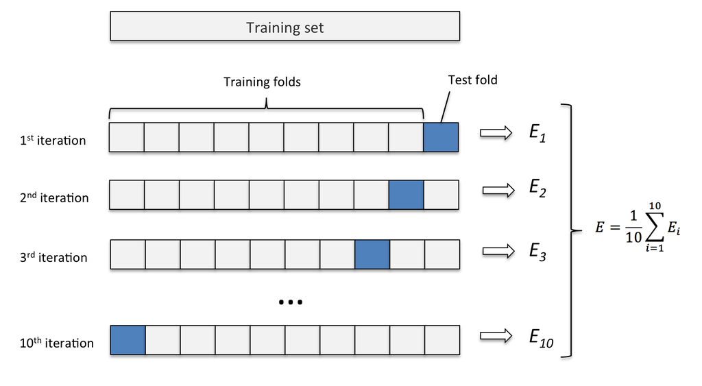

k-fold cross validation breaks the data into $k$ folds, e.g. 10 in the figure above. It then estimates a model using $k-1$ folds and uses the remaining fold as the “test” fold, aka “validation set.” The process is repeated again and again creating models for *each* fold.

Cross-Validation Parameters:

- `cp` - complexity parameter ; mesures trdeoff between model *complexity* nd *accuracy*

```r
library(caret)
library(e1071)
```

**Define number of folds using `trainControl` (from `caret`):**

We will use `method="cv"` for cross-validation.

```r
numFolds <- trainControl(method="cv", number = 10) # 10 for 10 folds
```

**Test over different `cp` values:**

```r
cpGrid <- expand.grid(.cp = seq(0.01,0.5,0.01))
```